# 5_Binary_regression

MariaGladkaya

2023-12-20

## Считываем дата-сет

```r
library(readxl)
df <- read_excel("~/spbu_studies/mat_statistics/MatStat4-6/datasets/Doctor.xlsx")
View(df)
```

#### В бинарной модели регрессии у может принимать ограниченное число значений. В бинарной - это 0 и 1.

Оценка методом максимального правдоподобия для нахождения оценок

Логит/пробит(норм. расп) модели

## Построение логит модели

### Построить описательную статистику с помощью функции summary.

Х1, Х2, Х3, Х5 - непрерывные. Х4 - категориальная

```r
summary(df)
```

```
##        y                x1              x2               x3
##  Min.   :0.0000   Min.   :11.00   Min.   : 3.300   Min.   : 1.000
##  1st Qu.:0.0000   1st Qu.:14.00   1st Qu.: 6.375   1st Qu.: 3.985
##  Median :1.0000   Median :16.00   Median :10.450   Median : 6.835
##  Mean   :0.6379   Mean   :16.33   Mean   :10.328   Mean   : 7.141
##  3rd Qu.:1.0000   3rd Qu.:19.00   3rd Qu.:13.400   3rd Qu.: 9.975
##  Max.   :1.0000   Max.   :27.00   Max.   :19.000   Max.   :16.000
##        x4              x5
##  Min.   :1.000   Min.   :  0.80
##  1st Qu.:1.000   1st Qu.: 22.11
##  Median :3.000   Median : 38.94
##  Mean   :2.345   Mean   : 45.13
##  3rd Qu.:3.000   3rd Qu.: 53.12
##  Max.   :3.000   Max.   :399.80
```

```r
sapply(df, sd)
```

```
##          y         x1         x2         x3         x4         x5
##  0.4847961  3.2139386  3.9577425  3.7493426  0.9281509 53.9561709
```

Среднее отклонение

### При необходимости создать категориальную переменную (функция factor).

#### Таблица сопряженности признаков

```r
xtabs(~y+x4, df)
```

```
##    x4
## y    1  2  3
##   0  7  1 13
##   1 11  1 25
```

x4 разбит на 3 категории

```r
df$x4 <- factor(df$x4)
```

### Построить базовую модель логистической регрессии с максимально возможным количеством предикторов с использованием функции glm.

### Протестировать значимость коэффициентов регрессии в отдельности.

```r
mylogit <- glm(y~x1+x2+x3+x4+x5, df, family=binomial("logit"))
summary(mylogit)
```

```
##
## Call:
## glm(formula = y ~ x1 + x2 + x3 + x4 + x5, family = binomial("logit"),
##     data = df)
##
## Coefficients:
##              Estimate Std. Error z value Pr(>|z|)
## (Intercept) -10.70095    3.69973  -2.892  0.00382 **
## x1            0.45959    0.17705   2.596  0.00944 **
## x2            0.81826    0.43646   1.875  0.06083 .
## x3           -0.37897    0.42125  -0.900  0.36832
## x42          -2.14618    4.14447  -0.518  0.60457
## x43           0.22639    0.84413   0.268  0.78855
## x5           -0.03383    0.02045  -1.654  0.09816 .
## ---
## Signif. codes:  0 '***' 0.001 '**' 0.01 '*' 0.05 '.' 0.1 ' ' 1
##
## (Dispersion parameter for binomial family taken to be 1)
##
##     Null deviance: 75.934  on 57  degrees of freedom
## Residual deviance: 39.251  on 51  degrees of freedom
## AIC: 53.251
##
## Number of Fisher Scoring iterations: 6
```

*Coefficients:*

- Estimate - оценки коэф-тов в ур-нии
- Std. Error, t value - стандартная ошибка и значение статистики Т
- Статистика Вальда (z-statistic)

  Н0: коэф-т равен 0 (не значим)

  ```
  принимаем => не значим

  отвергаем => значим (р < 0.05)
  ```

*AIC: 53.251* - Коэф. максимального правдоподобия (для оценки при минимизации этого коэф.)

*Критерий максимального правдоподобия* - разница между откл. остатков для модели с предикторами и нулевой моделью

- Null deviance: 75.934 on 57 degrees of freedom (нулевая модель)
- Residual deviance: 39.251 on 51 degrees of freedom

### Записать уравнение бинарной регрессии, используя оценки коэффициентов.

Логарифмическая зависимость

## Анализ базовой модели

### Проверить значимость регрессии в целом по критерию Вальда и максимального правдоподобия.

*Критерий максимального правдоподобия*

```r
with(mylogit, pchisq(null.deviance - deviance, df.null - df.residual, lower.tail = FALSE))
```

```
## [1] 2.030246e-06
```

H0: Все коэф-ты одновременно = 0

Отвергаем, значит ур. является значимым

*Критерий Вальда* - Terms - список коэф-тов, которые надо проверить на значимость

```r
library(aod)
wald.test(b = coef(mylogit), Sigma = vcov(mylogit), Terms = 2:7)
```

```
## Wald test:
## ----------
##
## Chi-squared test:
## X2 = 13.2, df = 6, P(> X2) = 0.04
```

Н0 о том, что коэф-ты незначимы отвергается

### Построить доверительные интервалы для коэффициентов регрессии (функции confint и confint.default).

```r
confint(mylogit)
```

```
##                    2.5 %       97.5 %
## (Intercept) -19.50621113 -4.630054171
## x1            0.15462038  0.868430365
## x2            0.14108761  1.949630035
## x3           -1.41817185  0.319468193
## x42          -9.44403808  3.640104684
## x43          -1.45888350  1.927761096
## x5           -0.07910068 -0.006760787
```

Доверительные интервалы построенные на стандартных ошибках

```r
confint.default(mylogit)
```

```
##                    2.5 %       97.5 %
## (Intercept) -17.95229371 -3.449603671
## x1            0.11257920  0.806603338
## x2           -0.03719091  1.673716157
## x3           -1.20459774  0.446664628
## x42         -10.26918747  5.976819488
## x43          -1.42807112  1.880841385
## x5           -0.07391230  0.006261571
```

## Построение пробит модели

### Провести сравнительный анализ логит и пробит моделей.

```r
myprobit <- glm(y~x1+x2+x3+x4+x5, df, family=binomial("probit"))
summary(myprobit)
```

```
##
## Call:
## glm(formula = y ~ x1 + x2 + x3 + x4 + x5, family = binomial("probit"),
##     data = df)
##
## Coefficients:
##             Estimate Std. Error z value Pr(>|z|)
## (Intercept) -6.12853    1.94100  -3.157  0.00159 **
## x1           0.26397    0.09484   2.783  0.00538 **
## x2           0.47466    0.23534   2.017  0.04370 *
## x3          -0.23146    0.23321  -0.992  0.32096
## x42         -1.23190    1.93357  -0.637  0.52405
## x43          0.09670    0.47985   0.202  0.84029
## x5          -0.01906    0.01125  -1.695  0.09014 .
## ---
## Signif. codes:  0 '***' 0.001 '**' 0.01 '*' 0.05 '.' 0.1 ' ' 1
##
## (Dispersion parameter for binomial family taken to be 1)
##
##     Null deviance: 75.934  on 57  degrees of freedom
## Residual deviance: 39.239  on 51  degrees of freedom
## AIC: 53.239
##
## Number of Fisher Scoring iterations: 7
```

*Coefficients:* x2 стал более значим

*AIC*: **53.239** < 53.251 - модель немного улучшилась

*Residual deviance:* **39.239** < 39.251

## Анализ базовой модели

### Проверить значимость регрессии в целом по критерию Вальда и максимального правдоподобия.

*Критерий максимального правдоподобия*

```r
with(myprobit, pchisq(null.deviance - deviance, df.null - df.residual, lower.tail = FALSE))
```

```
## [1] 2.019715e-06
```

H0: Все коэф-ты одновременно = 0

Отвергаем, значит ур. является значимым

*Критерий Вальда* - Terms - список коэф-тов, которые надо проверить на значимость

```r
library(aod)
wald.test(b = coef(myprobit), Sigma = vcov(myprobit), Terms = 2:7)
```

```
## Wald test:
## ----------
##
## Chi-squared test:
## X2 = 16.7, df = 6, P(> X2) = 0.011
```

Н0 о том, что коэф-ты незначимы отвергается

## Диагностика модели бинарной регрессии

```r
test.predicted.logit <- predict(mylogit, newdata = df, type = "response")
test.predicted.logit
```

```
##            1            2            3            4            5            6
## 0.0323228983 0.4758614198 0.1098865978 0.8743436090 0.2684105724 0.0307933000
##            7            8            9           10           11           12
## 0.5717812373 0.5746272673 0.0040075113 0.8458139553 0.3597199759 0.6272352551
##           13           14           15           16           17           18
## 0.9118042544 0.3248064625 0.9868368230 0.9946507572 0.5209360473 0.9743385306
##           19           20           21           22           23           24
## 0.6540557941 0.9939682866 0.9753805239 0.6757704082 0.9676771017 0.5742044023
##           25           26           27           28           29           30
## 0.1971584467 0.9939043647 0.9889821552 0.1282948208 0.9993057647 0.9819782728
##           31           32           33           34           35           36
## 0.9625408650 0.9081235830 0.9507562317 0.5989287472 0.8709711067 0.0001515524
##           37           38           39           40           41           42
## 0.9741707143 0.2104370062 0.3014881783 0.9685970373 0.9514652068 0.5025096983
##           43           44           45           46           47           48
## 0.0072948317 0.2830219797 0.7872135807 0.9695724375 0.9931752715 0.9787571888
##           49           50           51           52           53           54
## 0.0908913462 0.9559115950 0.9927752247 0.4601747664 0.9430684500 0.0933505488
##           55           56           57           58
## 0.6419921366 0.2577311018 0.9875762514 0.7384965451
```

```r
test.predicted.probit <- predict(myprobit, newdata = df, type = "response")
test.predicted.probit
```

```
##            1            2            3            4            5            6
## 2.704250e-02 4.524316e-01 1.143959e-01 8.708947e-01 2.904293e-01 2.532234e-02
##            7            8            9           10           11           12
## 5.660868e-01 5.500016e-01 8.314748e-04 8.334817e-01 3.621633e-01 5.952682e-01
##           13           14           15           16           17           18
## 8.945335e-01 3.367379e-01 9.918931e-01 9.981598e-01 5.331337e-01 9.776811e-01
##           19           20           21           22           23           24
## 6.170324e-01 9.978664e-01 9.778774e-01 6.425032e-01 9.729575e-01 5.503075e-01
##           25           26           27           28           29           30
## 2.099438e-01 9.975472e-01 9.940459e-01 1.373462e-01 9.999782e-01 9.849890e-01
##           31           32           33           34           35           36
## 9.667369e-01 8.941529e-01 9.445940e-01 5.814062e-01 8.504115e-01 3.329380e-07
##           37           38           39           40           41           42
## 9.792115e-01 2.239972e-01 3.051928e-01 9.703098e-01 9.478712e-01 4.937136e-01
##           43           44           45           46           47           48
## 2.397480e-03 2.950791e-01 7.542715e-01 9.721373e-01 9.979804e-01 9.846470e-01
##           49           50           51           52           53           54
## 9.399250e-02 9.577537e-01 9.970371e-01 4.537526e-01 9.411634e-01 9.100535e-02
##           55           56           57           58
## 6.078211e-01 2.581168e-01 9.931190e-01 7.124972e-01
```

### Построить таблицу сопряженности с пороговой вероятностью 0.5 (функция confusionMatrix).

TP (true positive) - правильно предсказанные положительные значения

TN (true negative) - правильно предсказанные отрицательные значения

```r
library(InformationValue)
confusionMatrix(df$y, test.predicted.logit, threshold = 0.5)
```

```
##    0  1
## 0 16  3
## 1  5 34
```

ок - не ок

не ок - ок

```r
confusionMatrix(df$y, test.predicted.probit, threshold = 0.5)
```

```
##    0  1
## 0 17  3
## 1  4 34
```

```r
library(InformationValue)
confusionMatrix(df$y, test.predicted.logit, threshold = 0.45)
```

```
##    0  1
## 0 14  3
## 1  7 34
```

```r
confusionMatrix(df$y, test.predicted.probit, threshold = 0.45)
```

```
##    0  1
## 0 14  3
## 1  7 34
```

```r
library(InformationValue)
confusionMatrix(df$y, test.predicted.logit, threshold = 0.55)
```

```
##    0  1
## 0 18  3
## 1  3 34
```

```r
confusionMatrix(df$y, test.predicted.probit, threshold = 0.55)
```

```
##    0  1
## 0 18  3
## 1  3 34
```

```r
library(InformationValue)
confusionMatrix(df$y, test.predicted.logit, threshold = 0.60)
```

```
##    0  1
## 0 18  7
## 1  3 30
```

```r
confusionMatrix(df$y, test.predicted.probit, threshold = 0.60)
```

```
##    0  1
## 0 18  8
## 1  3 29
```

#### оптимальное пороговое значение вероятности предсказания: 0.55

### Посчитать специфичность и чувствительность модели (функции sensitivity и specificity).

```r
sensitivity(df$y, test.predicted.logit, threshold = 0.5)
```

```
## [1] 0.9189189
```

```r
sensitivity(df$y, test.predicted.logit, threshold = 0.55)
```

```
## [1] 0.9189189
```

```r
sensitivity(df$y, test.predicted.logit, threshold = 0.6)
```

```
## [1] 0.8108108
```

```r
sensitivity(df$y, test.predicted.probit, threshold = 0.5)
```

```
## [1] 0.9189189
```

```r
sensitivity(df$y, test.predicted.probit, threshold = 0.55)
```

```
## [1] 0.9189189
```

```r
sensitivity(df$y, test.predicted.probit, threshold = 0.6)
```

```
## [1] 0.7837838
```

```r
specificity(df$y, test.predicted.logit, threshold = 0.4)
```

```
## [1] 0.6666667
```

```r
specificity(df$y, test.predicted.logit, threshold = 0.55)
```

```
## [1] 0.8571429
```

```r
specificity(df$y, test.predicted.logit, threshold = 0.7)
```

```
## [1] 0.9047619
```

```r
specificity(df$y, test.predicted.probit, threshold = 0.4)
```

```
## [1] 0.6666667
```

```r
specificity(df$y, test.predicted.probit, threshold = 0.55)
```

```
## [1] 0.8571429
```

```r
specificity(df$y, test.predicted.probit, threshold = 0.7)
```

```
## [1] 0.9047619
```

### Найти оптимальное пороговое значение вероятности предсказания. Построить таблицу сопряженности для этой вероятности, посчитать специфичность и чувствительность модели (функция optimalCutoff).

```r
optcutlogit <- optimalCutoff(df$y, test.predicted.logit)[1]
optcutlogit
```

```
## [1] 0.5293058
```

```r
confusionMatrix(df$y, test.predicted.logit, threshold = 0.5293058)
```

```
##    0  1
## 0 18  3
## 1  3 34
```

```r
optcutprobit <- optimalCutoff(df$y, test.predicted.probit)[1]
optcutprobit
```

```
## [1] 0.5399782
```

```r
confusionMatrix(df$y, test.predicted.probit, threshold = 0.5399782)
```

```
##    0  1
## 0 18  3
## 1  3 34
```

**Изменений не произошло**

### Построить ROC кривую, интерпретировать результаты (функция plotROC).

ROC суммирует производительность модели, оценивая компромисс между частотой истинных положит. рез-ов и частотой ложных положит. рез-ов (площадь подграфика)

Чем больше площадь подграфика, тем лучше, тем больше наблюдений были правильно предсказаны

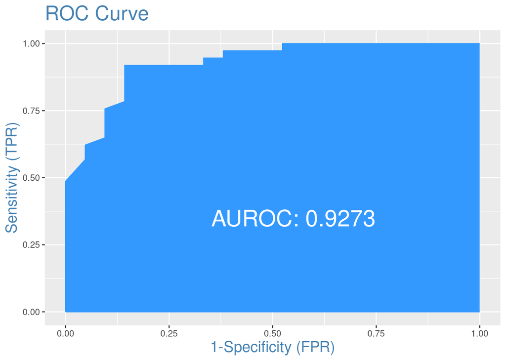

```r
plotROC(df$y, test.predicted.logit)
```

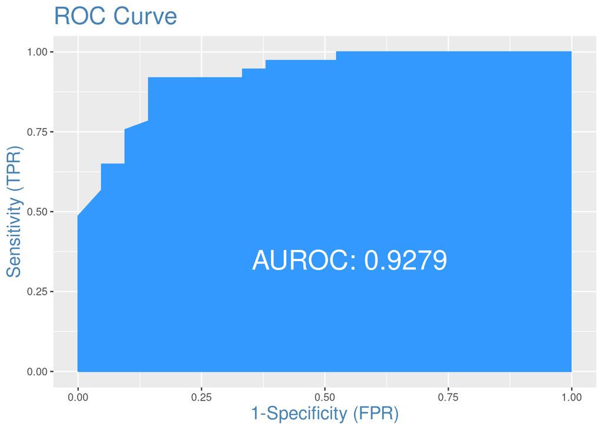

```r
plotROC(df$y, test.predicted.probit)
```

### Попробовать улучшить логит или пробит модель с использованием коэффициента AIC (функция stepAIC).

```r
library(MASS)
stepAIC(mylogit)
```

```
## Start:  AIC=53.25
## y ~ x1 + x2 + x3 + x4 + x5
##
##        Df Deviance    AIC
## - x4    2   39.737 49.737
## - x3    1   40.236 52.236
## <none>      39.251 53.251
## - x2    1   45.363 57.363
## - x5    1   47.802 59.802
## - x1    1   48.955 60.955
##
## Step:  AIC=49.74
## y ~ x1 + x2 + x3 + x5
##
##        Df Deviance    AIC
## - x3    1   40.618 48.618
## <none>      39.737 49.737
## - x2    1   45.824 53.824
## - x5    1   47.946 55.946
## - x1    1   49.205 57.205
##
## Step:  AIC=48.62
## y ~ x1 + x2 + x5
##
##        Df Deviance    AIC
## <none>      40.618 48.618
## - x5    1   48.250 54.250
## - x1    1   49.294 55.294
## - x2    1   60.197 66.197
```

```
##
## Call:  glm(formula = y ~ x1 + x2 + x5, family = binomial("logit"), data = df)
##
## Coefficients:
## (Intercept)           x1           x2           x5
##    -9.07857      0.40292      0.47596     -0.02954
##
## Degrees of Freedom: 57 Total (i.e. Null);  54 Residual
## Null Deviance:       75.93
## Residual Deviance: 40.62     AIC: 48.62
```

```r
library(MASS)
stepAIC(myprobit)
```

```
## Start:  AIC=53.24
## y ~ x1 + x2 + x3 + x4 + x5
##
##        Df Deviance    AIC
## - x4    2   39.756 49.756
## - x3    1   40.344 52.344
## <none>      39.239 53.239
## - x2    1   45.349 57.349
## - x5    1   47.915 59.915
## - x1    1   48.816 60.816
##
## Step:  AIC=49.76
## y ~ x1 + x2 + x3 + x5
##
##        Df Deviance    AIC
## - x3    1   40.789 48.789
## <none>      39.756 49.756
## - x2    1   45.901 53.901
## - x5    1   48.103 56.103
## - x1    1   49.045 57.045
##
## Step:  AIC=48.79
## y ~ x1 + x2 + x5
##
##        Df Deviance    AIC
## <none>      40.789 48.789
## - x5    1   48.633 54.633
## - x1    1   49.235 55.235
## - x2    1   59.979 65.979
```

```
##
## Call:  glm(formula = y ~ x1 + x2 + x5, family = binomial("probit"),
##     data = df)
##
## Coefficients:
## (Intercept)           x1           x2           x5
##    -5.10964      0.23041      0.26231     -0.01772
##
## Degrees of Freedom: 57 Total (i.e. Null);  54 Residual
## Null Deviance:       75.93
## Residual Deviance: 40.79     AIC: 48.79
```